# Клиенты банка, склонные к оттоку

**Описание:**  
региональный банк, расположенный в трёх российских городах - Ярославль, Рыбинск и Ростов Великий,  
столкнулся с проблемой оттока клиентов, масштабы которого угрожающе увеличиваются.  
Отделу маркетинга необходимо понять возможные причины такого поведения  
и разработать стратегию для удержания клиентов.  
Для анализа предоставлена следующая информация:  
идентификатор, пол и возраст клиента, город оформления банковского продукта,  
кредитный скоринг, баланс счёта, количество баллов собственности, количество продуктов,  
наличие кредитной карты, расчётный доход в месяц, активность за последние 30 дней, признак оттока.

**Задача:**  
выявить характерные признаки, указывающие на склонность к оттоку,  
разделить клиентов на несколько сегментов, приоритизировать сегменты по доле отточных,  
составить рекомендации для отдела маркетинга.

**Краткое содержание:**

- загрузим и исследуем данные;
- выделим основные признаки, влияющие на отток;
- проверим гипотезы;
- проведём сегментацию клиентов;
- сформулируем выводы и предложим рекомендации для снижения оттока.

## Часть 1. Знакомство с данными

На этом шаге:

- загрузим все необходимые библиотеки;
- сохраним предоставленные данные в переменную df;
- оценим объём и качество данных;
- изучим признаки и их тип (числовые или категориальные);
- проверим данные на наличие дубликатов;
- оценим количество пропусков.

```python
# импорт библиотек для работы с данными
import pandas as pd
import numpy as np
pd.options.display.float_format ='{:,.2f}'.format

# библиотеки для визуализации
import seaborn as sns
import matplotlib.pyplot as plt

# для статистического анализа
import scipy.stats as st
```

```python
# библиотека, позволяющая указывать несколько директорий хранения файла
import os

file_path_1 = 'C:/Users/havar/OneDrive/Рабочий стол/ЯндексПрактикум/АналитикДанныхРасширенный/ПРОЕКТЫ/Выпускной/bank_scrooge.csv'
file_path_2 = '/content/bank_scrooge.csv'

if os.path.exists(file_path_1):
    df = pd.read_csv(file_path_1, delimiter=',')
elif os.path.exists(file_path_2):
    df = pd.read_csv(file_path_2, delimiter=',')
else:
    print('Something is wrong')
```

```python
# первые строки датасета
df.head()
```

|  | USERID | score | city | gender | age | equity | balance | products | credit_card | last_activity | EST_SALARY | churn |
| --- | --- | --- | --- | --- | --- | --- | --- | --- | --- | --- | --- | --- |
| 0 | 183012 | 850.00 | Рыбинск | Ж | 25.00 | 1 | 59,214.82 | 2 | 0 | 1 | 75,719.14 | 1 |
| 1 | 146556 | 861.00 | Рыбинск | Ж | 37.00 | 5 | 850,594.33 | 3 | 1 | 0 | 86,621.77 | 0 |
| 2 | 120722 | 892.00 | Рыбинск | Ж | 30.00 | 0 | NaN | 1 | 1 | 1 | 107,683.34 | 0 |
| 3 | 225363 | 866.00 | Ярославль | Ж | 51.00 | 5 | 1,524,746.26 | 2 | 0 | 1 | 174,423.53 | 1 |
| 4 | 157978 | 730.00 | Ярославль | М | 34.00 | 5 | 174.00 | 1 | 1 | 0 | 67,353.16 | 1 |

```python
# нормализуем названия столбцов и выведем общую информацию о таблице
df.columns = map(str.lower, df.columns)
df.info()
```

```
<class 'pandas.core.frame.DataFrame'>
RangeIndex: 10000 entries, 0 to 9999
Data columns (total 12 columns):
 #   Column         Non-Null Count  Dtype
---  ------         --------------  -----
 0   userid         10000 non-null  int64
 1   score          10000 non-null  float64
 2   city           10000 non-null  object
 3   gender         10000 non-null  object
 4   age            9974 non-null   float64
 5   equity         10000 non-null  int64
 6   balance        7705 non-null   float64
 7   products       10000 non-null  int64
 8   credit_card    10000 non-null  int64
 9   last_activity  10000 non-null  int64
 10  est_salary     10000 non-null  float64
 11  churn          10000 non-null  int64
dtypes: float64(4), int64(6), object(2)
memory usage: 937.6+ KB
```

Описание данных:

- `userid` — идентификатор пользователя;
- `score` — баллы кредитного скоринга;
- `city` — город
- `gender` — пол;
- `age` — возраст;
- `equity` — количество баллов собственности;
- `balance` — баланс на счёте;
- `products` — количество продуктов, которыми пользуется клиент;
- `credit_card` — есть ли кредитная карта;
- `last_activity` — активность клиента за последние 30 дней;
- `est_salary` — оценочный доход клиента;
- `churn` — признак оттока.

```python
# количество дубликатов в колонке с id пользователя
df.userid.duplicated().sum()
```

```
73
```

```python
# список повторяющихся id пользователя
dupl = df.query('userid.duplicated() == True')
dupl.userid.unique()
```

```
array([190253, 210662, 131419, 187635, 220816, 221156, 208081, 170312,
       185748, 211130, 217643, 226719, 197364, 155765, 126368, 218868,
       151662, 143592, 141265, 208815, 152479, 217619, 208738, 120258,
       188957, 228075, 172142, 163207, 210135, 219343, 164676, 214031,
       140377, 117943, 116540, 210792, 191520, 198635, 226550, 149365,
       216848, 148826, 206759, 210898, 227795, 210627, 221197, 123461,
       181526, 162053, 127440, 199312, 222480, 183510, 200863, 150667,
       202983, 155872, 187459, 217826, 141945, 129785, 160075, 185829,
       221809, 171751, 195884, 163657, 124450, 168998, 140934, 217412,
       175730], dtype=int64)
```

```python
# строки с id 190253
df.query('userid == 190253')
```

|  | userid | score | city | gender | age | equity | balance | products | credit_card | last_activity | est_salary | churn |
| --- | --- | --- | --- | --- | --- | --- | --- | --- | --- | --- | --- | --- |
| 231 | 190253 | 823.00 | Рыбинск | М | 37.00 | 4 | 373,348.39 | 2 | 0 | 1 | 131,947.92 | 1 |
| 1583 | 190253 | 726.00 | Ярославль | М | 49.00 | 0 | NaN | 1 | 1 | 1 | 177,700.78 | 0 |

```python
# строки с id 175730
df.query('userid == 175730')
```

|  | userid | score | city | gender | age | equity | balance | products | credit_card | last_activity | est_salary | churn |
| --- | --- | --- | --- | --- | --- | --- | --- | --- | --- | --- | --- | --- |
| 7753 | 175730 | 846.00 | Ярославль | Ж | 32.00 | 7 | 216,764.74 | 4 | 1 | 1 | 77,100.85 | 1 |
| 9970 | 175730 | 816.00 | Рыбинск | М | 36.00 | 4 | 477,892.07 | 3 | 1 | 0 | 81,100.60 | 0 |

От сотрудников банка нам известно, что идентификатор пользователя - это всегда уникальное значение.  
Разные города для одного id можно объяснить перемещениями клиентов и оформлением банковского продукта в другом городе.  
Другими словами, клиент может приобрести разные продукты в разных городах, но все они будут оформлены на один уникальный номер id.  
Но в таблице также есть разное значение пола и возраста для одного id, разный кредитный скоринг, разный баланс и доход. Как будто это разные люди.  
Но так как это невозможно по правилам банка, будем считать данное наблюдение ошибкой ввода или вывода данных. Дубликаты удалим.

```python
# копия датасета до удаления дубликатов
df_copy = df.copy()

# удалим дубликаты
df = df.drop_duplicates(subset=['userid'])

# проверим результат
df.userid.duplicated().sum()
```

```
0
```

```python
# количество удалённых строк
len(df_copy) - len(df)
```

```
73
```

Проверим данные на наличие неявных дубликатов, которые могли образоваться в результате разного написания одних и тех же слов.

```python
# список уникальных названий городов
df.city.unique()
```

```
array(['Рыбинск', 'Ярославль', 'Ростов'], dtype=object)
```

```python
# список уникальных обозначений пола
df.gender.unique()
```

```
array(['Ж', 'М'], dtype=object)
```

Неявных дубликатов нет.

```python
# количество пропусков по каждой колонке
df.isna().sum().sort_values(ascending=False)
```

```
balance          2260
age                 4
userid              0
score               0
city                0
gender              0
equity              0
products            0
credit_card         0
last_activity       0
est_salary          0
churn               0
dtype: int64
```

```python
# доля пропусков по каждой колонке
df.isna().mean().sort_values(ascending=False)
```

```
balance         0.23
age             0.00
userid          0.00
score           0.00
city            0.00
gender          0.00
equity          0.00
products        0.00
credit_card     0.00
last_activity   0.00
est_salary      0.00
churn           0.00
dtype: float64
```

### Вывод 1

Таблица содержит 10 тысяч наблюдений по 12 признакам.  
6 признаков являются числовыми: кредитный скоринг, возраст, баллы собственности, баланс, количество продуктов и доход.  
3 признака являются бинарными или dummy-переменными, принимающими значения 0 и 1: кредитная карта, активность, признак оттока. В бинарный формат можно также перевести пол клиента и город.  
1 категориальный признак - id пользователя.  
В данных обнаружены дубликаты по id клиента - 73 строки. Удалены.  
В столбцах с возрастом и балансом есть пропуски.  
Из-за пропусков тип данных в столбце с возрастом - float, вместо int.

## Часть 2. Предобработка данных

На этом шаге:

- обработаем пропуски;
- исправим тип данных в столбце с возрастом;
- переведем пол и город в бинарный формат для построения матрицы корреляций.

4 пропуска с возрастом удалим, так как количество незначительное, а попытка заполнить чем-либо исказит результаты.

```python
# копия датасета до удаления пропусков
df_copy2 = df.copy()

# удаление пропусков в столбце 'age'
df = df.dropna(subset=['age'])

# количество пропусков в столбце с возрастом
df['age'].isna().sum()
```

```
0
```

```python
# количество удалённых строк
len(df_copy2) - len(df)
```

```
4
```

```python
# исправление типа данных на целочисленный
df['age'] = df['age'].astype('int')
```

```python
# процент пропусков в столбце 'balance'
df.balance.isna().mean()
```

```
0.22775370351708152
```

В столбце с балансом 23% пропусков.  
Удалить такое количество без ущерба для данных мы не можем.  
Заполнять средним или медианой также нецелесообразно, так как это исказит результаты.  
Посмотрим, есть ли в данных наблюдения с нулевым балансом:

```python
# минимальный баланс
df.balance.min()
```

```
0.0
```

Да, в таблице встречается нулевой баланс.  
Сравним статистику клиентов с нулевым балансом со статистикой клиентов с пропусками.

```python
# статистика по клиентам с нулевым балансом
df.query('balance == 0').describe()
```

|  | userid | score | age | equity | balance | products | credit_card | last_activity | est_salary | churn |
| --- | --- | --- | --- | --- | --- | --- | --- | --- | --- | --- |
| count | 2.00 | 2.00 | 2.00 | 2.00 | 2.00 | 2.00 | 2.00 | 2.00 | 2.00 | 2.00 |
| mean | 164,143.50 | 771.50 | 19.00 | 1.00 | 0.00 | 2.00 | 1.00 | 0.50 | 44,212.42 | 0.00 |
| std | 22,185.48 | 58.69 | 1.41 | 1.41 | 0.00 | 0.00 | 0.00 | 0.71 | 28,759.32 | 0.00 |
| min | 148,456.00 | 730.00 | 18.00 | 0.00 | 0.00 | 2.00 | 1.00 | 0.00 | 23,876.51 | 0.00 |
| 25% | 156,299.75 | 750.75 | 18.50 | 0.50 | 0.00 | 2.00 | 1.00 | 0.25 | 34,044.46 | 0.00 |
| 50% | 164,143.50 | 771.50 | 19.00 | 1.00 | 0.00 | 2.00 | 1.00 | 0.50 | 44,212.42 | 0.00 |
| 75% | 171,987.25 | 792.25 | 19.50 | 1.50 | 0.00 | 2.00 | 1.00 | 0.75 | 54,380.38 | 0.00 |
| max | 179,831.00 | 813.00 | 20.00 | 2.00 | 0.00 | 2.00 | 1.00 | 1.00 | 64,548.33 | 0.00 |

```python
# статистика по клиентам с пропусками в балансе
df.query('balance.isna()').describe()
```

|  | userid | score | age | equity | balance | products | credit_card | last_activity | est_salary | churn |
| --- | --- | --- | --- | --- | --- | --- | --- | --- | --- | --- |
| count | 2,260.00 | 2,260.00 | 2,260.00 | 2,260.00 | 0.00 | 2,260.00 | 2,260.00 | 2,260.00 | 2,260.00 | 2,260.00 |
| mean | 171,975.57 | 865.33 | 42.13 | 0.05 | NaN | 1.16 | 0.82 | 0.55 | 226,700.56 | 0.01 |
| std | 33,277.19 | 89.67 | 11.95 | 0.23 | NaN | 0.40 | 0.39 | 0.50 | 199,981.67 | 0.08 |
| min | 114,182.00 | 642.00 | 18.00 | 0.00 | NaN | 0.00 | 0.00 | 0.00 | 20,274.03 | 0.00 |
| 25% | 143,067.00 | 871.00 | 33.00 | 0.00 | NaN | 1.00 | 1.00 | 0.00 | 120,457.01 | 0.00 |
| 50% | 172,498.50 | 903.00 | 40.00 | 0.00 | NaN | 1.00 | 1.00 | 1.00 | 174,755.35 | 0.00 |
| 75% | 201,354.25 | 922.00 | 49.00 | 0.00 | NaN | 1.00 | 1.00 | 1.00 | 240,451.81 | 0.00 |
| max | 229,145.00 | 990.00 | 86.00 | 3.00 | NaN | 3.00 | 1.00 | 1.00 | 1,333,687.36 | 1.00 |

Как оказалось, нулевой баланс встречается только в двух случаях, что на уровне статистической погрешности.  
Таким образом, мы можем выделить клиентов с пропусками по балансу в отдельную категорию, заменив пропуски нулями.  
Другими словами, 0 на балансе теперь будет означать "нет данных".

```python
# замена пропусков на 0
df.loc[df.balance.isna() == True, 'balance'] = 0

# количество пропусков в столбце с балансом
df.balance.isna().sum()
```

```
0
```

Перед тем, как закодировать категориальные переменные пол и город в индикаторные 0/1, сохраним исходный датасет в отдельной переменной для удобства построения визуализаций.

```python
# копия датасета для построения визуализаций
banks = df.copy()
```

```python
# преобразуем пол в двоичный формат: 1 - мужчина, 0 - женщина
gender = {'gender': {'М':1, 'Ж':0}}
df = df.replace(gender)
df.head()
```

|  | userid | score | city | gender | age | equity | balance | products | credit_card | last_activity | est_salary | churn |
| --- | --- | --- | --- | --- | --- | --- | --- | --- | --- | --- | --- | --- |
| 0 | 183012 | 850.00 | Рыбинск | 0 | 25 | 1 | 59,214.82 | 2 | 0 | 1 | 75,719.14 | 1 |
| 1 | 146556 | 861.00 | Рыбинск | 0 | 37 | 5 | 850,594.33 | 3 | 1 | 0 | 86,621.77 | 0 |
| 2 | 120722 | 892.00 | Рыбинск | 0 | 30 | 0 | 0.00 | 1 | 1 | 1 | 107,683.34 | 0 |
| 3 | 225363 | 866.00 | Ярославль | 0 | 51 | 5 | 1,524,746.26 | 2 | 0 | 1 | 174,423.53 | 1 |
| 4 | 157978 | 730.00 | Ярославль | 1 | 34 | 5 | 174.00 | 1 | 1 | 0 | 67,353.16 | 1 |

```python
# закодируем город в бинарный формат
df = pd.get_dummies(df, prefix = '', prefix_sep = '', dtype=int, drop_first=False)
df.head()
```

|  | userid | score | gender | age | equity | balance | products | credit_card | last_activity | est_salary | churn | Ростов | Рыбинск | Ярославль |
| --- | --- | --- | --- | --- | --- | --- | --- | --- | --- | --- | --- | --- | --- | --- |
| 0 | 183012 | 850.00 | 0 | 25 | 1 | 59,214.82 | 2 | 0 | 1 | 75,719.14 | 1 | 0 | 1 | 0 |
| 1 | 146556 | 861.00 | 0 | 37 | 5 | 850,594.33 | 3 | 1 | 0 | 86,621.77 | 0 | 0 | 1 | 0 |
| 2 | 120722 | 892.00 | 0 | 30 | 0 | 0.00 | 1 | 1 | 1 | 107,683.34 | 0 | 0 | 1 | 0 |
| 3 | 225363 | 866.00 | 0 | 51 | 5 | 1,524,746.26 | 2 | 0 | 1 | 174,423.53 | 1 | 0 | 0 | 1 |
| 4 | 157978 | 730.00 | 1 | 34 | 5 | 174.00 | 1 | 1 | 0 | 67,353.16 | 1 | 0 | 0 | 1 |

```python
df.info()
```

```
<class 'pandas.core.frame.DataFrame'>
Int64Index: 9923 entries, 0 to 9999
Data columns (total 14 columns):
 #   Column         Non-Null Count  Dtype
---  ------         --------------  -----
 0   userid         9923 non-null   int64
 1   score          9923 non-null   float64
 2   gender         9923 non-null   int64
 3   age            9923 non-null   int32
 4   equity         9923 non-null   int64
 5   balance        9923 non-null   float64
 6   products       9923 non-null   int64
 7   credit_card    9923 non-null   int64
 8   last_activity  9923 non-null   int64
 9   est_salary     9923 non-null   float64
 10  churn          9923 non-null   int64
 11  Ростов         9923 non-null   int32
 12  Рыбинск        9923 non-null   int32
 13  Ярославль      9923 non-null   int32
dtypes: float64(3), int32(4), int64(7)
memory usage: 1007.8 KB
```

### Вывод 2

Удалили 73 строки с дубликатами по id пользователя и 4 строки с пропусками в столбце с возрастом.  
Пропуски в столбце с балансом заполнили нулями.  
Обозначение пола закодировали в бинарный формат: 1 - мужчина, 0 - женщина.  
Города также перевели в бинарный формат,  
заменив общий столбец city на три столбца отдельно для каждого города, где 0 - нет, 1 - да.  
Исходный датасет до кодировки сохранили в переменную banks.  
Тип данных с возрастом исправили на целочисленный.

## Часть 3. Исследовательский анализ данных

На этом шаге:

- изучим общую статистику;
- посмотрим на распределения признаков в разрезе оттока;
- построим матрицу корреляций.

### Общая статистика

```python
df.describe().T
```

|  | count | mean | std | min | 25% | 50% | 75% | max |
| --- | --- | --- | --- | --- | --- | --- | --- | --- |
| userid | 9,923.00 | 171,731.48 | 33,694.37 | 94,561.00 | 142,720.00 | 172,635.00 | 201,157.50 | 229,145.00 |
| score | 9,923.00 | 848.73 | 65.40 | 642.00 | 802.00 | 853.00 | 900.00 | 1,000.00 |
| gender | 9,923.00 | 0.50 | 0.50 | 0.00 | 0.00 | 1.00 | 1.00 | 1.00 |
| age | 9,923.00 | 42.73 | 12.18 | 18.00 | 33.00 | 40.00 | 51.00 | 86.00 |
| equity | 9,923.00 | 2.63 | 1.98 | 0.00 | 0.00 | 3.00 | 4.00 | 9.00 |
| balance | 9,923.00 | 639,611.57 | 1,777,946.59 | 0.00 | 63,675.68 | 376,590.60 | 805,244.39 | 119,113,552.01 |
| products | 9,923.00 | 1.87 | 0.79 | 0.00 | 1.00 | 2.00 | 2.00 | 5.00 |
| credit_card | 9,923.00 | 0.68 | 0.47 | 0.00 | 0.00 | 1.00 | 1.00 | 1.00 |
| last_activity | 9,923.00 | 0.52 | 0.50 | 0.00 | 0.00 | 1.00 | 1.00 | 1.00 |
| est_salary | 9,923.00 | 147,886.49 | 139,363.90 | 2,546.30 | 75,252.12 | 119,719.33 | 174,673.28 | 1,395,064.45 |
| churn | 9,923.00 | 0.18 | 0.39 | 0.00 | 0.00 | 0.00 | 0.00 | 1.00 |
| Ростов | 9,923.00 | 0.14 | 0.35 | 0.00 | 0.00 | 0.00 | 0.00 | 1.00 |
| Рыбинск | 9,923.00 | 0.27 | 0.44 | 0.00 | 0.00 | 0.00 | 1.00 | 1.00 |
| Ярославль | 9,923.00 | 0.59 | 0.49 | 0.00 | 0.00 | 1.00 | 1.00 | 1.00 |

В выборке одинаковое количество мужчин и женщин.  
Средний возраст клиентов 42-43 года. Минимальный возраст - 18 лет, максимальный - 86.  
Максимальный баланс на счёте 119 миллионов - выглядит как выброс.  
Так же обращает на себя внимание минимальный расчётный доход в 2,5 тысячи.  
Минимальное количество продуктов 0 может быть ошибкой, так как известно, что человек становится клиентом банка только при условии оформления какого-либо банковского продукта.  
68% клиентов имеют кредитную карту.  
Чуть больше половины клиентов проявляли какую-либо активность за последние 30 дней.  
Почти 60% всех клиентов приходится на Ярославль.  
Ушедших в отток клиентов - 18% от общего числа.

```python
# все наблюдения, в которых количество продуктов равно 0
df.query('products == 0')
```

|  | userid | score | gender | age | equity | balance | products | credit_card | last_activity | est_salary | churn | Ростов | Рыбинск | Ярославль |
| --- | --- | --- | --- | --- | --- | --- | --- | --- | --- | --- | --- | --- | --- | --- |
| 8957 | 147837 | 962.00 | 0 | 79 | 3 | 0.00 | 0 | 0 | 0 | 25,063.96 | 1 | 0 | 1 | 0 |

Учитывая довольно преклонный возраст клиентки и отсутствие средств на счёте можно предположить, что признак оттока связан с уходом из жизни. Но мы не знаем этого наверняка, поэтому удалим это единственное наблюдение с нулевым количеством продуктов.

```python
# копия датасета до удаления
df_copy3 = df.copy()

# удаление строки с нулевым количеством продуктов по индексу
df = df.drop (index = 8957)

# количество наблюдений, в которых products равно 0
len(df.query('products == 0'))
```

```
0
```

```python
# количество удалённых строк
len(df_copy3) - len(df)
```

```
1
```

```python
# удаление строки с нулевым количеством продуктов из таблицы "banks"
banks = banks.drop (index = 8957)
```

### Выбросы

Выброс - это наблюдение, которое лежит аномально далеко от других значений в наборе данных.  
Это может быть ошибка ввода/вывода данных,  
но может быть и просто редкий признак.

#### Низкие доходы

```python
# срез по доходу менее 10 тысяч
df.query('est_salary < 10000')
```

|  | userid | score | gender | age | equity | balance | products | credit_card | last_activity | est_salary | churn | Ростов | Рыбинск | Ярославль |
| --- | --- | --- | --- | --- | --- | --- | --- | --- | --- | --- | --- | --- | --- | --- |
| 505 | 205035 | 725.00 | 0 | 77 | 3 | 73.00 | 2 | 0 | 1 | 8,729.84 | 0 | 0 | 1 | 0 |
| 1700 | 155567 | 747.00 | 1 | 25 | 0 | 5,750.92 | 1 | 1 | 0 | 7,054.82 | 0 | 1 | 0 | 0 |
| 1753 | 161271 | 836.00 | 0 | 19 | 4 | 7,703.05 | 4 | 1 | 1 | 5,043.14 | 0 | 0 | 0 | 1 |
| 1883 | 151268 | 852.00 | 0 | 63 | 5 | 373,070.37 | 1 | 1 | 1 | 8,587.79 | 0 | 1 | 0 | 0 |
| 1988 | 160979 | 788.00 | 1 | 24 | 4 | 118,438.82 | 2 | 1 | 0 | 8,401.97 | 0 | 0 | 1 | 0 |
| 2174 | 143340 | 830.00 | 0 | 72 | 2 | 294,375.63 | 3 | 1 | 1 | 8,032.18 | 0 | 0 | 0 | 1 |
| 2186 | 201407 | 938.00 | 0 | 69 | 1 | 325,483.52 | 3 | 0 | 1 | 3,487.33 | 0 | 0 | 1 | 0 |
| 2663 | 140105 | 821.00 | 0 | 75 | 7 | 631,805.72 | 1 | 1 | 0 | 8,894.57 | 0 | 1 | 0 | 0 |
| 3606 | 187819 | 839.00 | 0 | 56 | 5 | 1,027,438.02 | 2 | 0 | 0 | 7,571.80 | 0 | 0 | 1 | 0 |
| 3689 | 219561 | 817.00 | 1 | 25 | 3 | 121,065.39 | 4 | 1 | 1 | 7,522.14 | 0 | 1 | 0 | 0 |
| 4799 | 193482 | 812.00 | 0 | 25 | 2 | 105,603.12 | 2 | 1 | 0 | 8,849.89 | 0 | 0 | 1 | 0 |
| 4860 | 193417 | 823.00 | 0 | 64 | 2 | 277,249.69 | 2 | 0 | 0 | 5,341.50 | 0 | 1 | 0 | 0 |
| 6044 | 176879 | 836.00 | 0 | 66 | 3 | 226,648.06 | 2 | 1 | 1 | 8,707.54 | 0 | 1 | 0 | 0 |
| 6087 | 166086 | 788.00 | 1 | 26 | 5 | 99,885.68 | 1 | 0 | 1 | 9,766.13 | 0 | 0 | 1 | 0 |
| 7637 | 147622 | 850.00 | 0 | 73 | 2 | 263,390.68 | 3 | 0 | 1 | 9,530.00 | 0 | 1 | 0 | 0 |
| 8783 | 114221 | 948.00 | 0 | 26 | 1 | 77,092.89 | 1 | 1 | 0 | 2,546.30 | 0 | 0 | 0 | 1 |
| 9124 | 148483 | 811.00 | 0 | 75 | 5 | 542,971.64 | 3 | 1 | 1 | 8,226.26 | 0 | 0 | 0 | 1 |
| 9299 | 211611 | 826.00 | 1 | 26 | 0 | 150,934.62 | 1 | 1 | 0 | 9,425.19 | 0 | 0 | 1 | 0 |
| 9365 | 171110 | 788.00 | 0 | 76 | 2 | 223,228.01 | 2 | 0 | 0 | 8,260.33 | 0 | 0 | 1 | 0 |

Довольно интересный получился срез:  
среди клиентов либо молодые люди, либо пожилые и все клиенты не отточные.  
Особый интерес вызывает клиент с id 187819 с балансом на счёте более миллиона и доходом 7,5 тысяч -  
ей 56 лет, 5 баллов собственности и не пользуется кредитной картой.  
В срезе также есть молодые люди с баллами собственности 3-5 и балансом 100 и более тысяч при небольшом доходе.  
А с другой стороны - женщина 77 лет, 3 балла собственности и баланс 73 рубля, доход 8.7 тысяч  
(правда, была активность за последний месяц, возможно, снятие наличных или перевод).  
Клиент с самым низким по всей выборке доходом -  
это девушка 26 лет из Ярославля, имеет 1 балл собственности, кредитную карту и 77 тысяч на счёте.  
Таким образом, можно предположить, что большинство клиентов с низкими доходами -  
это молодые люди (возможно, студенты) и пенсионеры, у которых есть родственники или опекуны, оказывающие им финансовую помощь.  
Другими словами, низкий уровень дохода - это не ошибка, а определённая категория клиентов.

#### Высокие доходы

```python
# срез с доходами от 1 миллиона рублей
df.query('est_salary > 1000000')
```

|  | userid | score | gender | age | equity | balance | products | credit_card | last_activity | est_salary | churn | Ростов | Рыбинск | Ярославль |
| --- | --- | --- | --- | --- | --- | --- | --- | --- | --- | --- | --- | --- | --- | --- |
| 125 | 227092 | 1,000.00 | 1 | 32 | 5 | 19,757,180.85 | 2 | 1 | 1 | 1,024,626.50 | 0 | 0 | 0 | 1 |
| 149 | 218801 | 958.00 | 1 | 34 | 0 | 0.00 | 1 | 1 | 0 | 1,292,825.74 | 0 | 0 | 0 | 1 |
| 178 | 226887 | 890.00 | 1 | 49 | 4 | 3,956,103.10 | 2 | 1 | 0 | 1,120,528.70 | 0 | 0 | 0 | 1 |
| 250 | 210357 | 766.00 | 1 | 27 | 0 | 0.00 | 1 | 1 | 0 | 1,015,754.12 | 0 | 0 | 0 | 1 |
| 296 | 204143 | 925.00 | 1 | 25 | 0 | 0.00 | 2 | 1 | 0 | 1,001,009.40 | 0 | 0 | 0 | 1 |
| 302 | 164876 | 942.00 | 1 | 40 | 0 | 0.00 | 1 | 1 | 0 | 1,256,537.74 | 0 | 0 | 0 | 1 |
| 663 | 180853 | 949.00 | 1 | 45 | 0 | 0.00 | 1 | 1 | 0 | 1,142,166.48 | 0 | 0 | 0 | 1 |
| 996 | 127574 | 749.00 | 1 | 35 | 0 | 0.00 | 1 | 1 | 0 | 1,071,600.78 | 0 | 0 | 0 | 1 |
| 1027 | 119793 | 1,000.00 | 1 | 50 | 5 | 12,909,691.02 | 1 | 1 | 0 | 1,253,653.40 | 0 | 0 | 0 | 1 |
| 1273 | 136567 | 961.00 | 1 | 31 | 0 | 0.00 | 1 | 1 | 0 | 1,015,386.14 | 1 | 0 | 0 | 1 |
| 1301 | 221610 | 954.00 | 0 | 65 | 0 | 0.00 | 1 | 0 | 0 | 1,076,227.99 | 0 | 0 | 0 | 1 |
| 1468 | 162749 | 940.00 | 1 | 32 | 2 | 4,508,306.65 | 2 | 1 | 0 | 1,260,919.56 | 0 | 0 | 0 | 1 |
| 1600 | 197637 | 785.00 | 1 | 41 | 0 | 0.00 | 1 | 1 | 0 | 1,307,090.18 | 0 | 0 | 0 | 1 |
| 1814 | 205696 | 718.00 | 1 | 25 | 0 | 0.00 | 1 | 1 | 1 | 1,180,070.17 | 0 | 0 | 0 | 1 |
| 1845 | 132310 | 756.00 | 1 | 61 | 0 | 0.00 | 1 | 1 | 1 | 1,106,453.04 | 0 | 0 | 0 | 1 |
| 2068 | 201574 | 983.00 | 1 | 54 | 3 | 11,060,145.42 | 2 | 0 | 1 | 1,046,662.18 | 0 | 0 | 0 | 1 |
| 2291 | 115628 | 980.00 | 0 | 35 | 6 | 1,813,817.40 | 2 | 1 | 1 | 1,130,928.15 | 0 | 0 | 0 | 1 |
| 2424 | 216987 | 941.00 | 1 | 35 | 0 | 0.00 | 1 | 1 | 0 | 1,121,684.22 | 0 | 0 | 0 | 1 |
| 2901 | 164659 | 700.00 | 0 | 60 | 0 | 0.00 | 2 | 1 | 1 | 1,033,801.28 | 0 | 0 | 0 | 1 |
| 3103 | 203255 | 999.00 | 1 | 36 | 4 | 10,641,153.66 | 2 | 0 | 0 | 1,042,118.22 | 0 | 0 | 0 | 1 |
| 3143 | 193935 | 920.00 | 1 | 35 | 0 | 0.00 | 1 | 1 | 1 | 1,087,009.59 | 0 | 0 | 0 | 1 |
| 3283 | 155712 | 958.00 | 1 | 56 | 5 | 3,797,685.28 | 2 | 1 | 1 | 1,185,539.68 | 0 | 0 | 0 | 1 |
| 3370 | 140920 | 741.00 | 0 | 46 | 0 | 0.00 | 1 | 1 | 1 | 1,214,615.32 | 0 | 0 | 0 | 1 |
| 3577 | 132066 | 941.00 | 0 | 33 | 0 | 0.00 | 1 | 1 | 0 | 1,010,637.75 | 0 | 0 | 0 | 1 |
| 3748 | 149547 | 698.00 | 0 | 41 | 0 | 0.00 | 1 | 1 | 1 | 1,093,305.09 | 0 | 0 | 0 | 1 |
| 3930 | 162174 | 960.00 | 0 | 58 | 4 | 426,392.77 | 2 | 0 | 0 | 1,008,647.93 | 0 | 0 | 0 | 1 |
| 4005 | 163640 | 912.00 | 1 | 35 | 4 | 15,624,095.80 | 2 | 0 | 1 | 1,395,064.45 | 0 | 0 | 0 | 1 |
| 4091 | 156736 | 983.00 | 1 | 24 | 0 | 0.00 | 2 | 0 | 1 | 1,134,459.80 | 0 | 0 | 0 | 1 |
| 4473 | 216422 | 956.00 | 1 | 27 | 0 | 0.00 | 1 | 1 | 0 | 1,333,687.36 | 0 | 0 | 0 | 1 |
| 4637 | 149430 | 961.00 | 1 | 37 | 5 | 4,054,667.81 | 3 | 0 | 0 | 1,363,549.52 | 0 | 0 | 0 | 1 |
| 4645 | 216411 | 951.00 | 1 | 51 | 7 | 8,612,191.25 | 4 | 1 | 1 | 1,048,772.81 | 1 | 0 | 0 | 1 |
| 5022 | 121489 | 976.00 | 1 | 33 | 5 | 3,683,418.21 | 2 | 1 | 0 | 1,059,197.75 | 0 | 0 | 0 | 1 |
| 5124 | 131849 | 911.00 | 0 | 31 | 5 | 5,102,651.08 | 3 | 0 | 0 | 1,056,085.68 | 0 | 0 | 0 | 1 |
| 5160 | 174746 | 731.00 | 0 | 30 | 0 | 0.00 | 2 | 1 | 0 | 1,296,838.08 | 0 | 0 | 0 | 1 |
| 5273 | 214332 | 943.00 | 0 | 44 | 0 | 0.00 | 1 | 1 | 1 | 1,025,315.82 | 0 | 0 | 0 | 1 |
| 5550 | 193209 | 933.00 | 1 | 31 | 0 | 0.00 | 1 | 1 | 1 | 1,058,923.29 | 0 | 0 | 0 | 1 |
| 5693 | 115473 | 955.00 | 1 | 37 | 0 | 0.00 | 1 | 0 | 0 | 1,016,911.93 | 0 | 0 | 0 | 1 |
| 5708 | 162331 | 916.00 | 1 | 50 | 5 | 4,362,619.72 | 4 | 1 | 1 | 1,022,536.72 | 1 | 0 | 0 | 1 |
| 5865 | 120519 | 948.00 | 0 | 58 | 0 | 0.00 | 1 | 1 | 1 | 1,087,045.85 | 0 | 0 | 0 | 1 |
| 6126 | 213236 | 955.00 | 1 | 35 | 0 | 0.00 | 1 | 1 | 1 | 1,094,180.41 | 0 | 0 | 0 | 1 |
| 6163 | 198495 | 794.00 | 0 | 41 | 0 | 0.00 | 1 | 1 | 0 | 1,176,946.66 | 0 | 0 | 0 | 1 |
| 6244 | 138336 | 921.00 | 0 | 39 | 0 | 0.00 | 2 | 1 | 1 | 1,093,763.67 | 0 | 0 | 0 | 1 |
| 6499 | 224019 | 936.00 | 1 | 31 | 5 | 2,931,344.63 | 2 | 0 | 1 | 1,108,269.91 | 1 | 0 | 0 | 1 |
| 6720 | 179582 | 742.00 | 0 | 54 | 0 | 0.00 | 2 | 1 | 1 | 1,108,338.87 | 0 | 0 | 0 | 1 |
| 6778 | 120257 | 732.00 | 1 | 35 | 0 | 0.00 | 1 | 1 | 1 | 1,032,974.96 | 0 | 0 | 0 | 1 |
| 6892 | 152005 | 927.00 | 0 | 34 | 5 | 3,782,453.73 | 3 | 0 | 1 | 1,142,435.95 | 1 | 0 | 0 | 1 |
| 7040 | 227762 | 742.00 | 0 | 31 | 0 | 0.00 | 1 | 1 | 0 | 1,112,272.62 | 0 | 0 | 0 | 1 |
| 8016 | 138788 | 939.00 | 0 | 41 | 0 | 0.00 | 1 | 1 | 0 | 1,016,777.65 | 0 | 0 | 0 | 1 |
| 8019 | 126189 | 934.00 | 1 | 39 | 0 | 0.00 | 1 | 1 | 1 | 1,226,911.03 | 0 | 0 | 0 | 1 |
| 8147 | 135243 | 951.00 | 1 | 38 | 5 | 14,134,432.03 | 2 | 1 | 0 | 1,281,547.73 | 0 | 0 | 0 | 1 |
| 8213 | 188837 | 750.00 | 1 | 53 | 0 | 0.00 | 1 | 1 | 0 | 1,162,181.88 | 0 | 0 | 0 | 1 |
| 8484 | 221720 | 1,000.00 | 0 | 35 | 5 | 21,549,943.63 | 2 | 0 | 0 | 1,051,902.65 | 0 | 0 | 0 | 1 |
| 9052 | 122486 | 944.00 | 1 | 41 | 0 | 0.00 | 1 | 1 | 1 | 1,071,226.54 | 0 | 0 | 0 | 1 |
| 9060 | 136649 | 741.00 | 0 | 43 | 0 | 0.00 | 1 | 1 | 0 | 1,027,463.69 | 0 | 0 | 0 | 1 |
| 9103 | 123965 | 939.00 | 1 | 34 | 5 | 9,346,657.08 | 1 | 1 | 1 | 1,263,028.49 | 1 | 0 | 0 | 1 |
| 9253 | 177375 | 758.00 | 0 | 31 | 0 | 0.00 | 3 | 1 | 0 | 1,064,019.29 | 0 | 0 | 0 | 1 |
| 9366 | 181981 | 914.00 | 0 | 44 | 0 | 0.00 | 2 | 1 | 0 | 1,107,132.01 | 0 | 0 | 0 | 1 |
| 9711 | 193979 | 754.00 | 0 | 53 | 0 | 0.00 | 1 | 1 | 0 | 1,261,408.41 | 0 | 0 | 0 | 1 |
| 9813 | 123334 | 713.00 | 1 | 58 | 0 | 0.00 | 2 | 1 | 1 | 1,060,562.13 | 0 | 0 | 0 | 1 |

В клуб зарплатных миллионеров входят исключительно жители Ярославля,  
при этом у значительной части из них 0 баллов собственности и 0 на балансе счёта.  
Ноль на счёте может быть ошибкой ввода/вывода данных или признаком того, что у клиента есть счета в других банках,  
а собственность может быть записана на детей и супругов.  
Т.е., высокие зарплаты - это также отдельная категория.

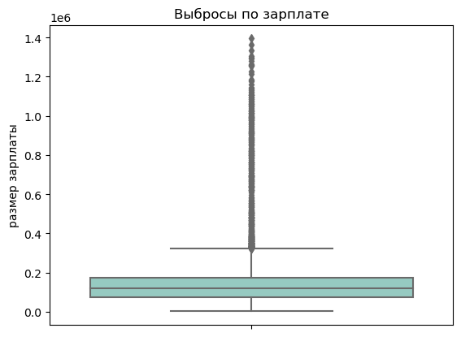

```python
# визуализация выбросов по зарплате
sns.boxplot(data=df,
            y='est_salary',
            palette='Set3')
plt.ylabel('размер зарплаты')
plt.title('Выбросы по зарплате');
```

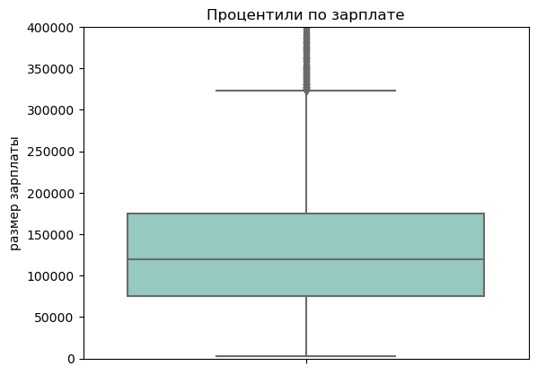

```python
# визуализация по зарплате с ограничением по оси Y
sns.boxplot(data=df,
            y='est_salary',
            palette='Set3')
plt.ylim(0, 400000)
plt.ylabel('размер зарплаты')
plt.title('Процентили по зарплате');
```

```python
# процентили по зарплате
df.est_salary.quantile([.25, .50, .75, .95])
```

```
0.25    75,254.04
0.50   119,735.43
0.75   174,679.64
0.95   316,862.99
Name: est_salary, dtype: float64
```

Большинство наблюдений лежат в диапазоне от 75 до 175 тысяч рублей.  
25% клиентов имеют доход от 2.5 до 75 тысяч,  
20% имеют доход от 175 до 317 тысяч  
и у 5% доходит до 1.4 миллиона.

```python
# минимальный доход
df.est_salary.min()
```

```
2546.3
```

```python
# максимальный доход
df.est_salary.max()
```

```
1395064.45
```

```python
# разделим выборку на две части:
# на оставшихся(0) и ушедших в отток(1)
churn_0 = df.query('churn == 0')
churn_1 = df.query('churn == 1')
```

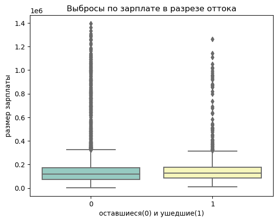

```python
# визуализация выбросов по зарплате в разрезе оттока
sns.boxplot(data=df,
            x='churn',
            y='est_salary',
            palette='Set3')
plt.xlabel('оставшиеся(0) и ушедшие(1)')
plt.ylabel('размер зарплаты')
plt.title('Выбросы по зарплате в разрезе оттока');
```

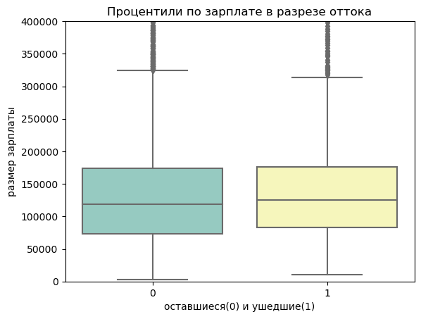

```python
# визуализация по зарплате в разрезе оттока
# с ограничением по оси Y
sns.boxplot(data=df,
            x='churn',
            y='est_salary',
            palette='Set3')
plt.ylim(0, 400000)
plt.xlabel('оставшиеся(0) и ушедшие(1)')
plt.ylabel('размер зарплаты')
plt.title('Процентили по зарплате в разрезе оттока');
```

```python
# процентили по зарплате оставшихся клиентов
salary_percentile_0 = (churn_0['est_salary']
                       .quantile([.25, .50, .75, .95])
                       .reset_index()
                       .rename(columns={'index': 'процентиль',
                                        'est_salary': 'зарплата_оставшихся'}))

# процентили по зарплате ушедших клиентов
salary_percentile_1 = (churn_1['est_salary']
                       .quantile([.25, .50, .75, .95])
                       .reset_index()
                       .rename(columns={'index': 'процентиль',
                                        'est_salary': 'зарплата_ушедших'}))

# объединение в одну таблицу
salary_percentile = pd.merge(salary_percentile_0,
                             salary_percentile_1,
                             on='процентиль')
salary_percentile
```

|  | процентиль | зарплата_оставшихся | зарплата_ушедших |
| --- | --- | --- | --- |
| 0 | 0.25 | 73,487.07 | 83,285.66 |
| 1 | 0.50 | 118,248.51 | 125,408.88 |
| 2 | 0.75 | 174,106.04 | 176,017.84 |
| 3 | 0.95 | 320,951.55 | 304,056.79 |

Статистика по зарплате в группе ушедших хоть и не сильно, но отличается от оставшихся -  
немного выше медиана, первый и третий квартили, а 95 процентиль, напротив, ниже  
и максимальный выброс имеет меньшее значение.  
Максимальная отточность наблюдается в группе клиентов с зарплатой в пределах 125 тысяч.  
Посмотрим распределение зарплат на гистограмме, но сначала ограничим выборку отсечением правого хвоста,  
чтобы выбросы не мешали визуальной оценке.

```python
# срезы по зарплате до 350 тыс. и признаку отточности
df_2 = df.query('est_salary < 350000')
churn_0_2 = df_2.query('churn == 0')
churn_1_2 = df_2.query('churn == 1')
```

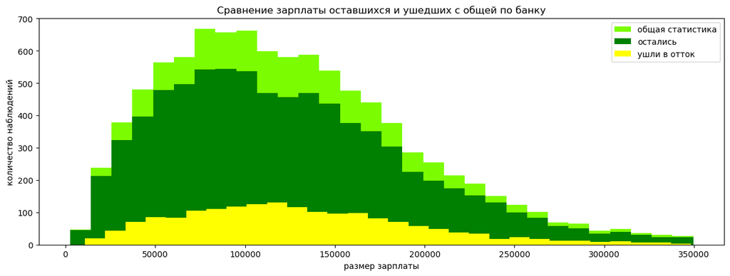

```python
# визуализация распределения зарплат по группам отточных и оставшихся
# в сравнении с общей статистикой
n_bins = 30
plt.subplots(figsize = (15,5))

plt.hist(df_2.est_salary,
         n_bins,
         color='LawnGreen',
         label='общая статистика')

plt.hist(churn_0_2.est_salary,
         n_bins,
         color='Green',
         label='остались')

plt.hist(churn_1_2.est_salary,
         n_bins,
         color='Yellow',
         label='ушли в отток')

plt.xlabel('размер зарплаты')
plt.ylabel('количество наблюдений')
plt.title('Сравнение зарплаты оставшихся и ушедших с общей по банку')
plt.legend();
```

Пик распределения для отточных клиентов относительно оставшихся смещён вправо, в сторону бОльших зарплат.

#### Максимальный баланс

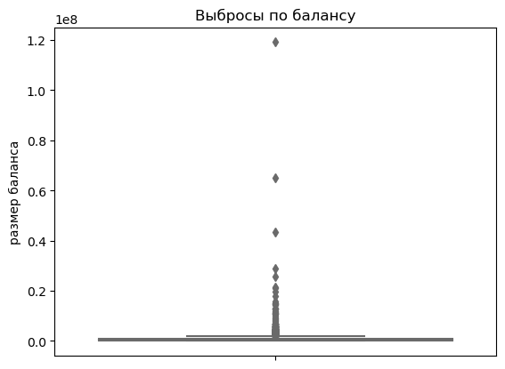

```python
# визуализация выбросов по балансу
sns.boxplot(data=df,
            y='balance',
            palette='Set3')
plt.ylabel('размер баланса')
plt.title('Выбросы по балансу');
```

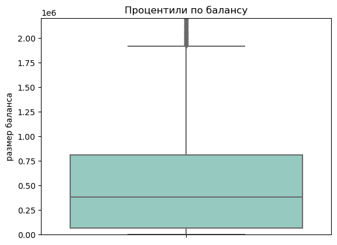

```python
# визуализация по балансу с ограничением по оси Y
sns.boxplot(data=df,
            y='balance',
            palette='Set3')
plt.ylim(0, 2200000)
plt.ylabel('размер баланса')
plt.title('Процентили по балансу');
```

```python
# процентили по балансу
df.balance.quantile([.25, .50, .75, .95])
```

```
0.25      63,741.43
0.50     376,715.58
0.75     805,331.39
0.95   1,847,426.28
Name: balance, dtype: float64
```

Ящик с усами заметно смещён вниз в сторону нуля, что отражает большое количество счетов с нулевым балансом.  
Четверть клиентов имеют на балансе не более 64 тысяч рублей.  
У половины клиентов баланс не превышает 377 тысяч.  
У 5% на счёте хранится свыше 1.8 миллиона.  
Другими словами, типичным балансом для данной выборки являются суммы от 64 до 805 тысяч,  
25% имеют низкий баланс от 0 до 64 тысяч, 20% высокий - от 805 тыс. до 1.8 млн.  
и 5% выбросов от 1.8 до 119 млн.

```python
# максимальный баланс
df.balance.max()
```

```
119113552.01
```

```python
# срез с балансом от 100 миллионов
df.query('balance > 100000000')
```

|  | userid | score | gender | age | equity | balance | products | credit_card | last_activity | est_salary | churn | Ростов | Рыбинск | Ярославль |
| --- | --- | --- | --- | --- | --- | --- | --- | --- | --- | --- | --- | --- | --- | --- |
| 7597 | 156149 | 900.00 | 1 | 62 | 5 | 119,113,552.01 | 2 | 1 | 1 | 138,041.31 | 0 | 0 | 0 | 1 |

Владелец счёта с балансом 119 миллионов - мужчина предпенсионного возраста из Ярославля, 5 баллов собственности, доход 138  
тысяч, был активен последние 30 дней, пользуется двумя продуктами, есть кредитная карта.  
Данное наблюдение хоть и очень редкое, но теоретически, вполне реалистичное.  
У нас нет оснований утверждать, что это ошибка.

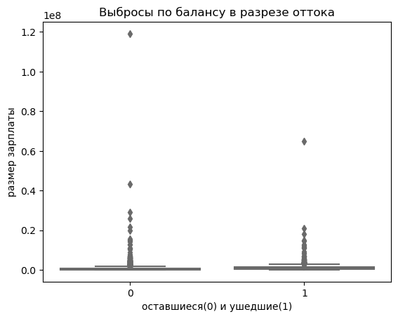

```python
# визуализация выбросов по балансу в разрезе оттока
sns.boxplot(data=df,
            x='churn',
            y='balance',
            palette='Set3')
plt.xlabel('оставшиеся(0) и ушедшие(1)')
plt.ylabel('размер зарплаты')
plt.title('Выбросы по балансу в разрезе оттока');
```

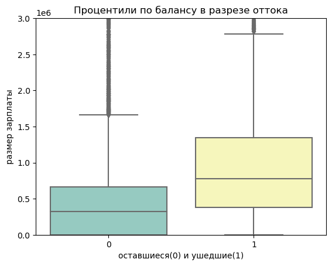

```python
# визуализация по балансу в разрезе оттока
# с ограничением по оси Y
sns.boxplot(data=df,
            x='churn',
            y='balance',
            palette='Set3')
plt.ylim(0, 3000000)
plt.xlabel('оставшиеся(0) и ушедшие(1)')
plt.ylabel('размер зарплаты')
plt.title('Процентили по балансу в разрезе оттока');
```

```python
# процентили по балансу оставшихся клиентов
balance_percentile_0 = (churn_0['balance']
                        .quantile([.25, .50, .75, .95])
                        .reset_index()
                        .rename(columns={'index': 'процентиль',
                                        'balance': 'баланс_оставшихся'}))

# процентили по балансу ушедших клиентов
balance_percentile_1 = (churn_1['balance']
                        .quantile([.25, .50, .75, .95])
                        .reset_index()
                        .rename(columns={'index': 'процентиль',
                                        'balance': 'баланс_ушедших'}))

# объединение в одну таблицу
balance_percentile = pd.merge(balance_percentile_0,
                              balance_percentile_1,
                              on='процентиль')
balance_percentile
```

|  | процентиль | баланс_оставшихся | баланс_ушедших |
| --- | --- | --- | --- |
| 0 | 0.25 | 0.00 | 382,038.08 |
| 1 | 0.50 | 321,692.92 | 775,399.47 |
| 2 | 0.75 | 665,669.85 | 1,347,250.18 |
| 3 | 0.95 | 1,448,353.69 | 2,980,906.85 |

В отличие от зарплаты, статистика по балансу между группой оставшихся и ушедших заметно отличается -  
все процентили для ушедших клиентов практически в два раза больше,  
а максимальный выброс значительно меньше.  
Посмотрим распределение баланса на гистограмме,  
Но сначала ограничим датасет по балансу от 2.5 тысяч до 1.5 миллиона,  
поскольку большое количество нулей (более 2 тысяч наблюдений) и выбросы помешают визуальной оценке.

```python
f'Количество наблюдений с нулевым балансом: {len(df.query("balance == 0"))}'
```

```
'Количество наблюдений с нулевым балансом: 2261'
```

```python
# срезы по балансу от 2.5 тыс. до 1.5 млн.
# и признаку отточности
df_3 = df.query('balance > 2500 & balance < 1500000')
churn_0_3 = df_3.query('churn == 0')
churn_1_3 = df_3.query('churn == 1')
```

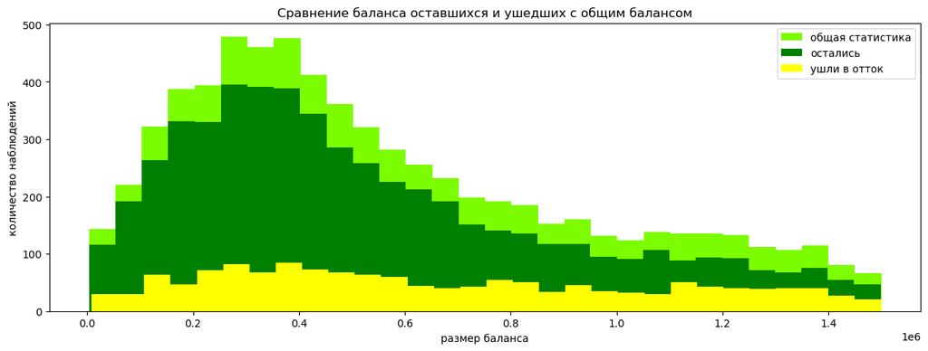

```python
# визуализация распределения баланса по группам отточных и оставшихся
# в сравнении с общей статистикой
n_bins = 30
plt.subplots(figsize = (15,5))

plt.hist(df_3.balance,
         n_bins,
         color='LawnGreen',
         label='общая статистика')

plt.hist(churn_0_3.balance,
         n_bins,
         color='Green',
         label='остались')

plt.hist(churn_1_3.balance,
         n_bins,
         color='Yellow',
         label='ушли в отток')

plt.xlabel('размер баланса')
plt.ylabel('количество наблюдений')
plt.title('Сравнение баланса оставшихся и ушедших с общим балансом')
plt.legend();
```

```python
x = len(df.query('balance > est_salary')) / len(df) * 100
f'Процент клиентов, у которых баланс больше дохода: {round(x)}'
```

```
'Процент клиентов, у которых баланс больше дохода: 73'
```

Подавляющее большинство клиентов склонны к накоплению и ,возможно, активному приумножению своих доходов.

### Распределение признаков

Распределение признака - это закономерность встречаемости разных его значений.  
Когда крайние значения признака встречаются достаточно редко,  
а близкие к средней величине - достаточно часто,  
такое распределение считается нормальным.

#### Функции

##### stat_group

```python
def stat_group(sign, x_0, группа_0, x_1, группа_1):
    """Функция для вывода статистики для определённого признака по двум группам клиентов.

    На вход функция принимает название признака,
    столбец с признаком из первого и столбец с признаком из второго среза данных (x_0 и x_1),
    которые образовались при делении датасета на какие-либо две группы.
    А также названия полученных групп, например:
    мужчины и женщины, оставшиеся и ушедшие и т.п.
    """
    pass
    d_0 = x_0.describe().reset_index()
    d_0.columns = [sign, группа_0]
    d_1 = x_1.describe().reset_index()
    d_1.columns = [sign, группа_1]
    d = pd.merge(d_0, d_1, left_on=sign, right_on=sign)
    display(d)
```

##### countplot_group

```python
def countplot_group(x_0, группа_0, x_1, группа_1, X_name, Y_name, title):
    """Функция для построения графиков частоты встречаемости признака по двум группам клиентов.

    На вход функция принимает признак из первого и признак из второго среза данных (x_0 и x_1),
    которые образовались при делении датасета на какие-либо две группы.
    А также названия полученных групп, например:
    мужчины и женщины, оставшиеся и ушедшие и т.п.,
    названия осей X и Y, название графика.
    """
    pass
    plt.subplots(figsize = (15,5))
    sns.countplot(x=x_0, color='Yellow', label=группа_0)
    sns.countplot(x=x_1, color='Green', label=группа_1, alpha=.66)
    sns.set_context(rc={'font.size':11})
    plt.xlabel(X_name)
    plt.ylabel(Y_name)
    plt.title(title)
    plt.legend();
```

#### Возраст клиентов

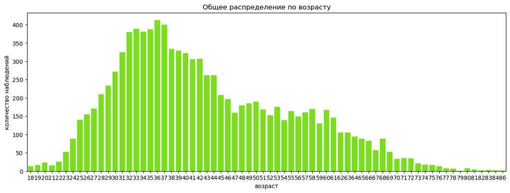

```python
# визуализация общего распределения клиентов по возрасту
plt.subplots(figsize = (15,5))
sns.countplot(x=df.age, color='LawnGreen')
sns.set_context(rc={'font.size':10})
plt.xlabel('возраст')
plt.ylabel('количество наблюдений')
plt.title('Общее распределение по возрасту');
```

```python
# общая статистика для возраста по группам
stat_group('возраст',
           churn_0.age, 'оставшиеся',
           churn_1.age, 'отток')
```

|  | возраст | оставшиеся | отток |
| --- | --- | --- | --- |
| 0 | count | 8,104.00 | 1,818.00 |
| 1 | mean | 43.02 | 41.43 |
| 2 | std | 12.37 | 11.14 |
| 3 | min | 18.00 | 18.00 |
| 4 | 25% | 34.00 | 32.00 |
| 5 | 50% | 40.00 | 39.00 |
| 6 | 75% | 51.00 | 52.00 |
| 7 | max | 86.00 | 75.00 |

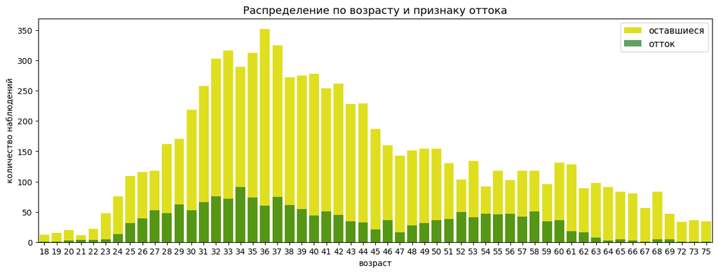

```python
# график частоты встречаемости каждого возраста по группам
countplot_group(churn_0['age'], 'оставшиеся',
                churn_1['age'], 'отток',
                'возраст',
                'количество наблюдений',
                'Распределение по возрасту и признаку оттока')
```

Для группы оставшихся клиентов мы видим распределение по возрасту близкое к нормальному, но с заметной асимметрией вправо.  
А в группе отточных проявилось бимодальное распределение, разделившее выборку на условно "молодых" и "пожилых".  
Среди "молодых" из группы оттока пик приходится на 34 года, среди "пожилых" два пика - 52 и 58 лет.

```python
# квантили по возрасту
df.age.quantile([.25, .50, .75, .95])
```

```
0.25   33.00
0.50   40.00
0.75   51.00
0.95   65.00
Name: age, dtype: float64
```

#### Количество продуктов

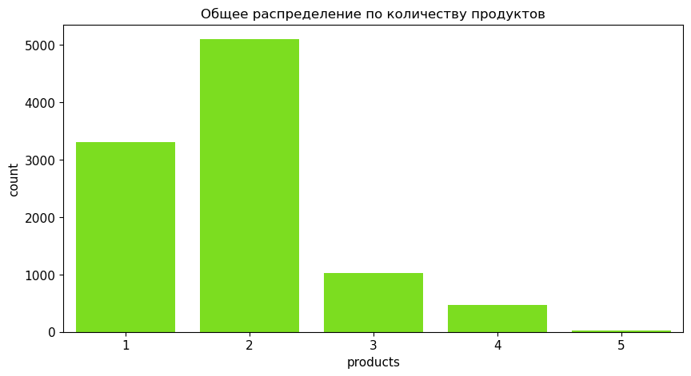

```python
# визуализация общего распределения клиентов по количеству используемых продуктов
plt.subplots(figsize = (10,5))
sns.countplot(x=df.products, color='LawnGreen')
sns.set_context(rc={'font.size':10})
plt.title('Общее распределение по количеству продуктов');
```

```python
# общая статистика по количеству продуктов и признаку оттока
stat_group('количество_продуктов',
           churn_0.products, 'оставшиеся',
           churn_1.products, 'отток')
```

|  | количество_продуктов | оставшиеся | отток |
| --- | --- | --- | --- |
| 0 | count | 8,104.00 | 1,818.00 |
| 1 | mean | 1.76 | 2.38 |
| 2 | std | 0.71 | 0.92 |
| 3 | min | 1.00 | 1.00 |
| 4 | 25% | 1.00 | 2.00 |
| 5 | 50% | 2.00 | 2.00 |
| 6 | 75% | 2.00 | 3.00 |
| 7 | max | 5.00 | 5.00 |

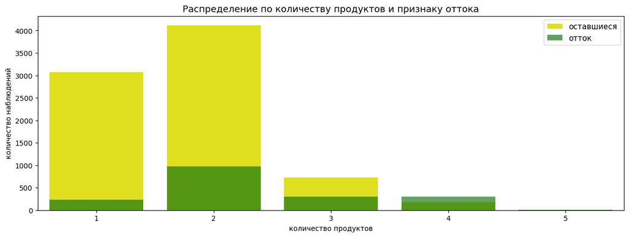

```python
# распределение количества продуктов по признаку оттока
countplot_group(churn_0['products'], 'оставшиеся',
                churn_1['products'], 'отток',
                'количество продуктов',
                'количество наблюдений',
                'Распределение по количеству продуктов и признаку оттока')
```

Распределение среди оставшихся совпадает с общим распределением - большинство клиентов пользуются двумя продуктами.  
Для отточных клиентов распределение отличается тем, что группа с тремя продуктами больше группы с одним, а группа с четырьмя продуктами равна группе с тремя и это единственная группа, в которой количество отточных клиентов преобладает над оставшимися.

#### Баллы собственности

```python
# общая статистика по баллам собственности и признаку оттока
stat_group('баллы собственности',
           churn_0.equity, 'оставшиеся',
           churn_1.equity, 'отток')
```

|  | баллы собственности | оставшиеся | отток |
| --- | --- | --- | --- |
| 0 | count | 8,104.00 | 1,818.00 |
| 1 | mean | 2.38 | 3.76 |
| 2 | std | 1.97 | 1.59 |
| 3 | min | 0.00 | 0.00 |
| 4 | 25% | 0.00 | 3.00 |
| 5 | 50% | 3.00 | 4.00 |
| 6 | 75% | 4.00 | 5.00 |
| 7 | max | 9.00 | 9.00 |

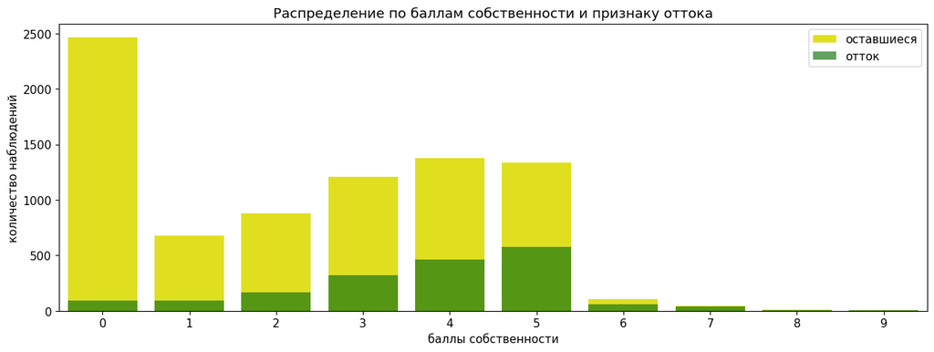

```python
# распределение по баллам собственности и признаку оттока
countplot_group(churn_0['equity'], 'оставшиеся',
                churn_1['equity'], 'отток',
                'баллы собственности',
                'количество наблюдений',
                'Распределение по баллам собственности и признаку оттока')
```

Большинство ушедших клиентов имели 4-5 баллов собственности.  
Среди оставшихся больше тех, у кого 0 баллов.

#### Кредитная карта

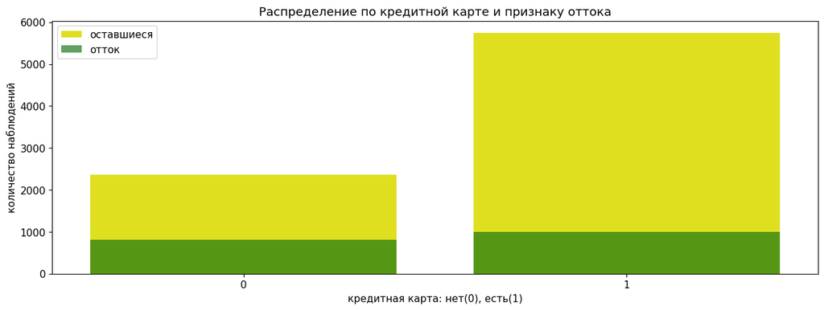

```python
# распределение по наличию кредитной карты и признаку оттока
countplot_group(churn_0['credit_card'], 'оставшиеся',
                churn_1['credit_card'], 'отток',
                'кредитная карта: нет(0), есть(1)',
                'количество наблюдений',
                'Распределение по кредитной карте и признаку оттока')
```

Среди отточных клиентов держателей кредитной карты и тех, у кого её нет, примерно поровну.  
Среди оставшихся - без карты вполовину меньше.

#### Активность за последние 30 дней

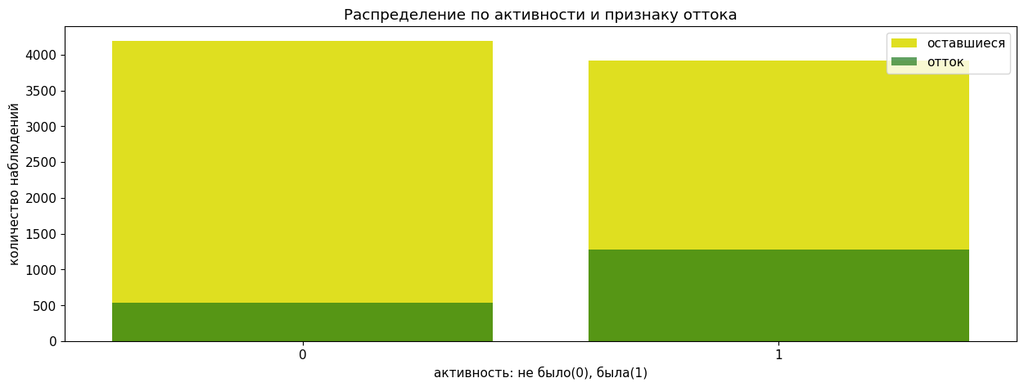

```python
# распределение по активности и признаку оттока
countplot_group(churn_0['last_activity'], 'оставшиеся',
                churn_1['last_activity'], 'отток',
                'активность: не было(0), была(1)',
                'количество наблюдений',
                'Распределение по активности и признаку оттока')
```

Большинство отточных клиентов проявляли активность за последние 30 дней.

#### Баланс и зарплата

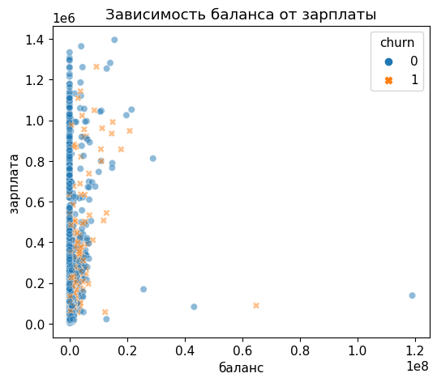

```python
# корреляция между балансом и зарплатой
plt.subplots(figsize = (6,5))
sns.scatterplot(x='balance',
                y='est_salary',
                data=df,
                hue='churn',
                style='churn',
                alpha = 0.5)
plt.xlabel('баланс')
plt.ylabel('зарплата')
plt.title('Зависимость баланса от зарплаты');
```

Практически при любом уровне дохода баланс может быть нулевым.  
Особенно это характерно для оставшихся клиентов и в меньшей степени для отточных.  
Редко, но встречается большой баланс при сравнительно небольшой зарплате.

#### Кредитный скоринг

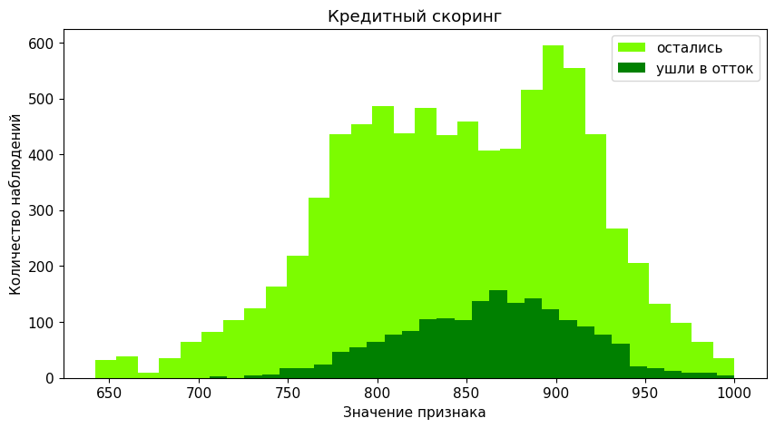

```python
# распределение кредитного скоринга
n_bins = 30
plt.subplots(figsize = (10,5))

plt.hist(churn_0.score,
         n_bins,
         color = 'LawnGreen',
         label='остались')

plt.hist(churn_1.score,
         n_bins,
         color = 'Green',
         label='ушли в отток')

plt.xlabel('Значение признака')
plt.ylabel('Количество наблюдений')
plt.title('Кредитный скоринг')
plt.legend();
```

#### Матрица корреляций

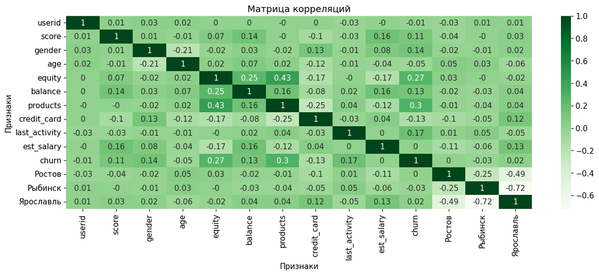

```python
cm = df.corr().round(2)
fig, ax = plt.subplots(figsize=(15, 5))
sns.heatmap(cm, cmap="Greens", annot=True)
plt.title('Матрица корреляций')
plt.xlabel('Признаки')
plt.ylabel('Признаки');
```

С признаком оттока больше всего коррелируют количество продуктов и балл собственности.  
Между этими двумя признаками также есть взаимная корреляция.  
Есть небольшая зависимость между количеством продуктов и балансом.  
Учитывая предыдущий анализ, для сегментации клиентов лучше выбрать балл собственности и количество продуктов.

### Вывод 3

73% клиентов склонны к накоплению средств, на что указывает баланс, превышающий доходы.  
Большинство клиентов из Ярославля, мужчин и женщин примерно поровну, возраст - от 18 до 86 лет.  
В данных о зарплате и доходах есть выбросы, которые, скорее всего, не являются ошибкой, а просто редкие наблюдения.

Отточных клиентов - 18% от всей выборки.  
Больше всего на отток влияет количество используемых продуктов.  
Среди тех, кто пользуется 4 продуктами, отточных больше, чем оставшихся.

Большинство клиентов с 4 продуктами также имеют высокие доходы, но для сегментации этот признак лучше не использовать,  
так как среди зарплатных миллионеров есть достаточное число клиентов с нулевым балансом на счёте и 0 баллами собственности.  
Баланс может быть нулевым практически при любом уровне дохода.  
Среди использующих 4 продукта нет клиентов с нулевым балансом.  
Нулевой баланс чаще всего встречается у клиентов с нулевым баллом собственности.

## Часть 4. Проверка гипотез

В этой части проверим две гипотезы о том:

- различаются ли доходы между оставшимися и ушедшими в отток клиентами;
- различается ли количество продуктов, которыми пользуются оставшиеся и отточные клиенты?

### Гипотеза 1

Попытаемся определить, есть ли различия в доходах между двумя группами клиентов - оставшихся и ушедших.  
Для этого создадим две выборки: salary_0 и salary_1.  
Сравним их между собой, используя метод для проверки гипотезы о равенстве среднего двух генеральных совокупностей.  
Сформулируем гипотезы.  
**Нулевая гипотеза**: средние значения доходов оставшихся клиентов и клиентов, ушедших в отток, равны.  
**Альтернативная гипотеза**: среднее значение доходов оставшихся клиентов выше, чем среднее значение доходов ушедших.

```python
# доходы оставшихся клиентов
salary_0 = (df
            .query('churn == 0')
            .est_salary)

# доходы отточных клиентов
salary_1 = (df
            .query('churn == 1')
            .est_salary)
```

```python
# зададим уровень значимости
alpha = 0.05

# проведём ttest для двух выборок, в качестве альтернативной используем одностороннюю гипотезу «больше»
# используем аргумент equal_var, так как выборки не равны по размеру
results = st.ttest_ind(salary_0,
                       salary_1,
                       alternative='greater',
                       equal_var=False)

print(f'p-value: {results.pvalue}')

# проверим p-value
if results.pvalue < alpha:
    print('Отвергаем нулевую гипотезу')
else:
    print('Нет оснований отвергнуть нулевую гипотезу')
```

```
p-value: 0.5677364493234351
Нет оснований отвергнуть нулевую гипотезу
```

Мы сравниваем два среза из одного и того же набора данных.  
Поэтому для проверки гипотезы используем критерий Стьюдента,  
который применяется для сравнения двух выборок из одной и той же генеральной совокупности.  
Конкурирующая гипотеза правосторонняя, т.е. предположение смещено в сторону бОльших значений в выборке,  
поэтому используется аргумент 'greater' (больше).

### Гипотеза 2

Попробуем определить, есть ли разница между средним количеством используемых продуктов в группе оставшихся и группе ушедших клиентов.  
Для этого сравним две выборки: среднее количество продуктов для оставшихся (products_0) и для ушедших (products_1) по методу Стьюдента.

**Нулевая гипотеза:**  
Среднее количество используемых банковских продуктов в группе оставшихся и в группе ушедших клиентов одинаково.  
**Альтернативная гипотеза:**  
Среднее количество продуктов в группе оставшихся меньше, чем в группе ушедших.

```python
# количество продуктов для группы оставшихся
products_0 = (df
              .query('churn == 0')
              .products)

# количество продуктов для группы ушедших
products_1 = (df
              .query('churn == 1')
              .products)
```

```python
# зададим уровень значимости
alpha = 0.05

# проведём ttest для двух выборок, в качестве альтернативной используем одностороннюю гипотезу «меньше»
# используем аргумент equal_var, так как выборки не равны по размеру
results = st.ttest_ind(products_0,
                       products_1,
                       alternative='less',
                       equal_var=False)

print(f'p-value: {results.pvalue}')

# проверим p-value
if results.pvalue < alpha:
    print('Отвергаем нулевую гипотезу')
else:
    print('Нет оснований отвергнуть нулевую гипотезу')
```

```
p-value: 4.093368272545767e-139
Отвергаем нулевую гипотезу
```

Для проверки второй гипотезы мы также сравниваем две выборки из одной генеральной совокупности  
и поэтому также используем критерий Стьюдента.  
Альтернативная гипотеза в этот раз левосторонняя, т.е. предположение смещено в сторону меньших значений в выборке,  
поэтому используется аргумент 'less' (меньше).

Результат проверки гипотез говорит нам о том, что с вероятностью 95% можно предположить:

- размер зарплаты слабо влияет на признак оттока, этот критерий не стоит использовать для сегментации клиентов;
- количество используемых продуктов, вероятно, оказывает значимое влияние на отток, можно использовать для сегментации.

### Вывод 4

Для проверки гипотез мы использовали метод проверки равенства среднего двух генеральных совокупностей.  
В первом случае мы не смогли отвергнуть нулевую гипотезу и оставили версию, что доходы оставшихся клиентов и ушедших в отток примерно одинаковы.  
Во втором случае нулевую гипотезу можно отвергнуть и согласиться с тем, что среднее количество используемых продуктов в группе оставшихся меньше, чем в группе ушедших.

## Часть 5. Сегментация клиентов

Учитывая результаты исследования, разделим выборку на 4 сегмента  
по количеству баллов собственности и числу используемых банковских продуктов.  
Дадим метафорические названия каждому сегменту по аналогии с водителями различных транспортных средств:

- `сегмент №1` - до 5 баллов собственности и количество продуктов 1-2 - `bicyclist` (велосипедист);
- `сегмент №2` - до 5 баллов собственности и количество продуктов 3-5 - `biker` (байкер);
- `сегмент №3` - от 5 баллов собственности и количество продуктов 1-2 - `motorist` (автомобилист);
- `сегмент №4` - от 5 баллов собственности и количество продуктов 3-5 - `racer` (гонщик).

```python
# нарезка по сегментам
bicyclist = df.query('equity < 5 & products < 3')
biker = df.query('equity < 5 & products > 2')
motorist = df.query('equity > 4 & products < 3')
racer = df.query('equity > 4 & products > 2')
```

### Сегмент №1

```python
# несколько строк из сегмента №1
bicyclist.head()
```

|  | userid | score | gender | age | equity | balance | products | credit_card | last_activity | est_salary | churn | Ростов | Рыбинск | Ярославль |
| --- | --- | --- | --- | --- | --- | --- | --- | --- | --- | --- | --- | --- | --- | --- |
| 0 | 183012 | 850.00 | 0 | 25 | 1 | 59,214.82 | 2 | 0 | 1 | 75,719.14 | 1 | 0 | 1 | 0 |
| 2 | 120722 | 892.00 | 0 | 30 | 0 | 0.00 | 1 | 1 | 1 | 107,683.34 | 0 | 0 | 1 | 0 |
| 7 | 218868 | 825.00 | 0 | 38 | 4 | 458,145.40 | 2 | 1 | 1 | 68,085.48 | 0 | 0 | 0 | 1 |
| 9 | 133130 | 906.00 | 0 | 67 | 0 | 0.00 | 1 | 0 | 1 | 238,055.53 | 0 | 0 | 0 | 1 |
| 10 | 148929 | 927.00 | 1 | 52 | 0 | 0.00 | 1 | 1 | 1 | 196,820.07 | 0 | 1 | 0 | 0 |

```python
# общая статистика по сегменту №1
bicyclist.describe()
```

|  | userid | score | gender | age | equity | balance | products | credit_card | last_activity | est_salary | churn | Ростов | Рыбинск | Ярославль |
| --- | --- | --- | --- | --- | --- | --- | --- | --- | --- | --- | --- | --- | --- | --- |
| count | 6,764.00 | 6,764.00 | 6,764.00 | 6,764.00 | 6,764.00 | 6,764.00 | 6,764.00 | 6,764.00 | 6,764.00 | 6,764.00 | 6,764.00 | 6,764.00 | 6,764.00 | 6,764.00 |
| mean | 171,681.80 | 844.44 | 0.51 | 42.52 | 1.77 | 419,183.73 | 1.56 | 0.74 | 0.52 | 153,187.63 | 0.12 | 0.15 | 0.29 | 0.57 |
| std | 33,481.02 | 69.90 | 0.50 | 12.15 | 1.60 | 1,125,977.43 | 0.50 | 0.44 | 0.50 | 145,052.51 | 0.32 | 0.35 | 0.45 | 0.50 |
| min | 94,561.00 | 642.00 | 0.00 | 18.00 | 0.00 | 0.00 | 1.00 | 0.00 | 0.00 | 2,546.30 | 0.00 | 0.00 | 0.00 | 0.00 |
| 25% | 142,638.50 | 794.00 | 0.00 | 33.00 | 0.00 | 0.00 | 1.00 | 0.00 | 0.00 | 77,808.73 | 0.00 | 0.00 | 0.00 | 0.00 |
| 50% | 172,461.50 | 848.00 | 1.00 | 40.00 | 2.00 | 234,594.64 | 2.00 | 1.00 | 1.00 | 123,054.14 | 0.00 | 0.00 | 0.00 | 1.00 |
| 75% | 201,179.50 | 900.00 | 1.00 | 51.00 | 3.00 | 499,112.05 | 2.00 | 1.00 | 1.00 | 178,956.75 | 0.00 | 0.00 | 1.00 | 1.00 |
| max | 229,145.00 | 1,000.00 | 1.00 | 86.00 | 4.00 | 64,866,210.15 | 2.00 | 1.00 | 1.00 | 1,395,064.45 | 1.00 | 1.00 | 1.00 | 1.00 |

Общий признак этого сегмента - не более 4 баллов собственности и 1-2 банковских продукта.  
Женщин и мужчин, а также активных и неактивных клиентов примерно поровну.  
Кредитной картой владеют 74%. Средний баланс - 419 тысяч.  
Средний возраст 42.5 года.  
Ушедших в отток - 12%.

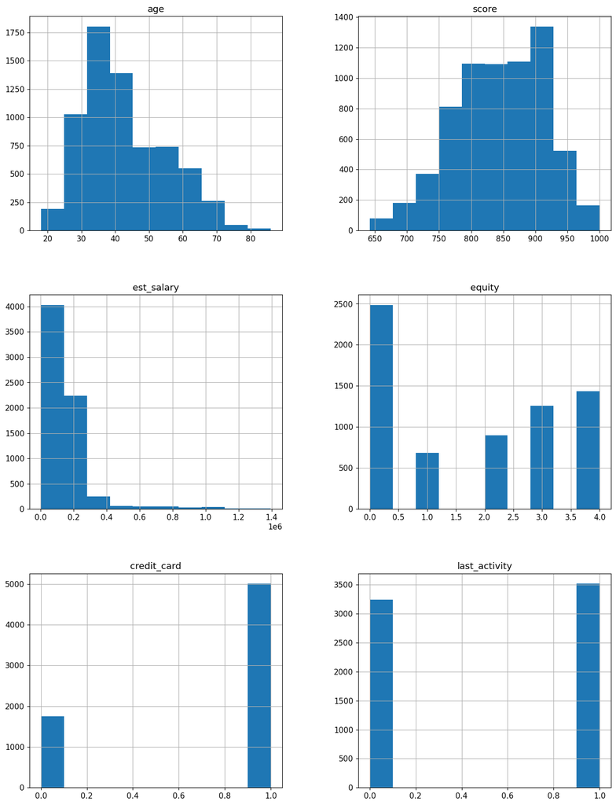

```python
# визуализация статистики для "велосипедистов"
(bicyclist[['age', 'score', 'est_salary',
           'equity', 'credit_card', 'last_activity']]
 .hist(figsize=(15, 20)));
```

### Сегмент №2

```python
# несколько строк из сегмента №2
biker.head()
```

|  | userid | score | gender | age | equity | balance | products | credit_card | last_activity | est_salary | churn | Ростов | Рыбинск | Ярославль |
| --- | --- | --- | --- | --- | --- | --- | --- | --- | --- | --- | --- | --- | --- | --- |
| 5 | 202305 | 856.00 | 1 | 56 | 4 | 863,687.24 | 3 | 1 | 0 | 156,619.80 | 0 | 0 | 1 | 0 |
| 6 | 177259 | 807.00 | 0 | 39 | 3 | 405,042.44 | 3 | 0 | 1 | 103,838.32 | 0 | 0 | 0 | 1 |
| 15 | 120260 | 731.00 | 1 | 42 | 3 | 1,480,548.47 | 3 | 1 | 0 | 160,974.43 | 0 | 0 | 1 | 0 |
| 26 | 174396 | 898.00 | 0 | 62 | 3 | 364,049.27 | 3 | 0 | 1 | 50,661.84 | 0 | 0 | 0 | 1 |
| 33 | 125478 | 786.00 | 0 | 27 | 3 | 448,062.52 | 3 | 1 | 1 | 37,607.67 | 0 | 1 | 0 | 0 |

```python
# общая статистика по сегменту №2
biker.describe()
```

|  | userid | score | gender | age | equity | balance | products | credit_card | last_activity | est_salary | churn | Ростов | Рыбинск | Ярославль |
| --- | --- | --- | --- | --- | --- | --- | --- | --- | --- | --- | --- | --- | --- | --- |
| count | 979.00 | 979.00 | 979.00 | 979.00 | 979.00 | 979.00 | 979.00 | 979.00 | 979.00 | 979.00 | 979.00 | 979.00 | 979.00 | 979.00 |
| mean | 170,870.12 | 840.13 | 0.44 | 43.75 | 2.88 | 890,367.22 | 3.29 | 0.46 | 0.52 | 128,521.18 | 0.35 | 0.11 | 0.17 | 0.72 |
| std | 33,195.88 | 56.58 | 0.50 | 12.70 | 1.24 | 1,288,687.32 | 0.48 | 0.50 | 0.50 | 106,215.61 | 0.48 | 0.31 | 0.38 | 0.45 |
| min | 96,267.00 | 689.00 | 0.00 | 19.00 | 0.00 | 0.00 | 3.00 | 0.00 | 0.00 | 3,487.33 | 0.00 | 0.00 | 0.00 | 0.00 |
| 25% | 142,585.50 | 796.00 | 0.00 | 34.00 | 2.00 | 297,991.77 | 3.00 | 0.00 | 0.00 | 68,510.83 | 0.00 | 0.00 | 0.00 | 0.00 |
| 50% | 172,343.00 | 834.00 | 0.00 | 40.00 | 3.00 | 545,495.01 | 3.00 | 0.00 | 1.00 | 112,035.03 | 0.00 | 0.00 | 0.00 | 1.00 |
| 75% | 197,529.50 | 880.00 | 1.00 | 53.00 | 4.00 | 1,201,318.29 | 4.00 | 1.00 | 1.00 | 160,476.95 | 1.00 | 0.00 | 0.00 | 1.00 |
| max | 229,058.00 | 1,000.00 | 1.00 | 83.00 | 4.00 | 25,727,761.86 | 5.00 | 1.00 | 1.00 | 1,064,019.29 | 1.00 | 1.00 | 1.00 | 1.00 |

Общий признак этого сегмента - не более 4 баллов собственности и более 2 банковских продукта.  
Женщин немного больше, чем мужчин, активных и неактивных клиентов примерно поровну.  
Кредитной картой владеют 46%. Средний баланс - 890 тысяч.  
Средний возраст 43-44 года.  
Ушедших в отток - 35%.

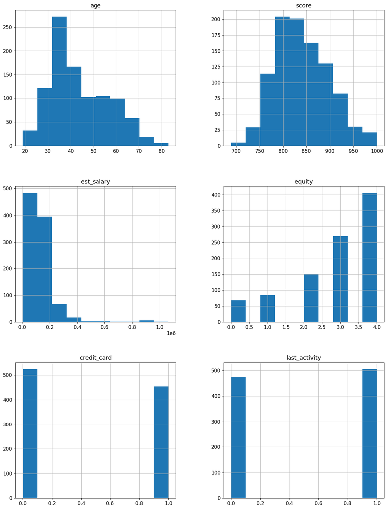

```python
# визуализация статистики для "байкеров"
(biker[['age', 'score', 'est_salary',
           'equity', 'credit_card', 'last_activity']]
 .hist(figsize=(15, 20)));
```

### Сегмент №3

```python
# несколько строк из сегмента №3
motorist.head()
```

|  | userid | score | gender | age | equity | balance | products | credit_card | last_activity | est_salary | churn | Ростов | Рыбинск | Ярославль |
| --- | --- | --- | --- | --- | --- | --- | --- | --- | --- | --- | --- | --- | --- | --- |
| 3 | 225363 | 866.00 | 0 | 51 | 5 | 1,524,746.26 | 2 | 0 | 1 | 174,423.53 | 1 | 0 | 0 | 1 |
| 4 | 157978 | 730.00 | 1 | 34 | 5 | 174.00 | 1 | 1 | 0 | 67,353.16 | 1 | 0 | 0 | 1 |
| 8 | 211686 | 923.00 | 1 | 54 | 5 | 1,206,337.87 | 2 | 1 | 0 | 155,371.79 | 0 | 0 | 0 | 1 |
| 14 | 172138 | 815.00 | 1 | 35 | 5 | 547,499.87 | 2 | 1 | 1 | 105,883.26 | 0 | 0 | 0 | 1 |
| 16 | 123335 | 829.00 | 1 | 45 | 5 | 507,842.84 | 1 | 1 | 1 | 169,330.64 | 0 | 0 | 0 | 1 |

```python
# общая статистика по сегменту №3
motorist.describe()
```

|  | userid | score | gender | age | equity | balance | products | credit_card | last_activity | est_salary | churn | Ростов | Рыбинск | Ярославль |
| --- | --- | --- | --- | --- | --- | --- | --- | --- | --- | --- | --- | --- | --- | --- |
| count | 1,637.00 | 1,637.00 | 1,637.00 | 1,637.00 | 1,637.00 | 1,637.00 | 1,637.00 | 1,637.00 | 1,637.00 | 1,637.00 | 1,637.00 | 1,637.00 | 1,637.00 | 1,637.00 |
| mean | 171,597.23 | 864.94 | 0.49 | 42.59 | 5.18 | 1,161,741.33 | 1.80 | 0.63 | 0.52 | 138,076.82 | 0.26 | 0.16 | 0.29 | 0.55 |
| std | 34,007.75 | 49.14 | 0.50 | 11.85 | 0.57 | 3,282,177.73 | 0.40 | 0.48 | 0.50 | 129,054.61 | 0.44 | 0.37 | 0.45 | 0.50 |
| min | 96,404.00 | 724.00 | 0.00 | 19.00 | 5.00 | 174.00 | 1.00 | 0.00 | 0.00 | 7,571.80 | 0.00 | 0.00 | 0.00 | 0.00 |
| 25% | 141,897.00 | 829.00 | 0.00 | 33.00 | 5.00 | 546,988.62 | 2.00 | 0.00 | 0.00 | 71,999.44 | 0.00 | 0.00 | 0.00 | 0.00 |
| 50% | 171,794.00 | 868.00 | 0.00 | 40.00 | 5.00 | 794,822.87 | 2.00 | 1.00 | 1.00 | 114,636.06 | 0.00 | 0.00 | 0.00 | 1.00 |
| 75% | 200,465.00 | 901.00 | 1.00 | 51.00 | 5.00 | 1,189,905.04 | 2.00 | 1.00 | 1.00 | 165,970.28 | 1.00 | 0.00 | 1.00 | 1.00 |
| max | 228,908.00 | 1,000.00 | 1.00 | 78.00 | 9.00 | 119,113,552.01 | 2.00 | 1.00 | 1.00 | 1,281,547.73 | 1.00 | 1.00 | 1.00 | 1.00 |

Общий признак этого сегмента - от 5 баллов собственности и 1-2 банковских продукта.  
Женщин и мужчин, а также активных и неактивных клиентов примерно поровну.  
Кредитной картой владеют 63%. Средний баланс - 1.1 миллиона.  
Средний возраст 42.5 года.  
Ушедших в отток - 26%.

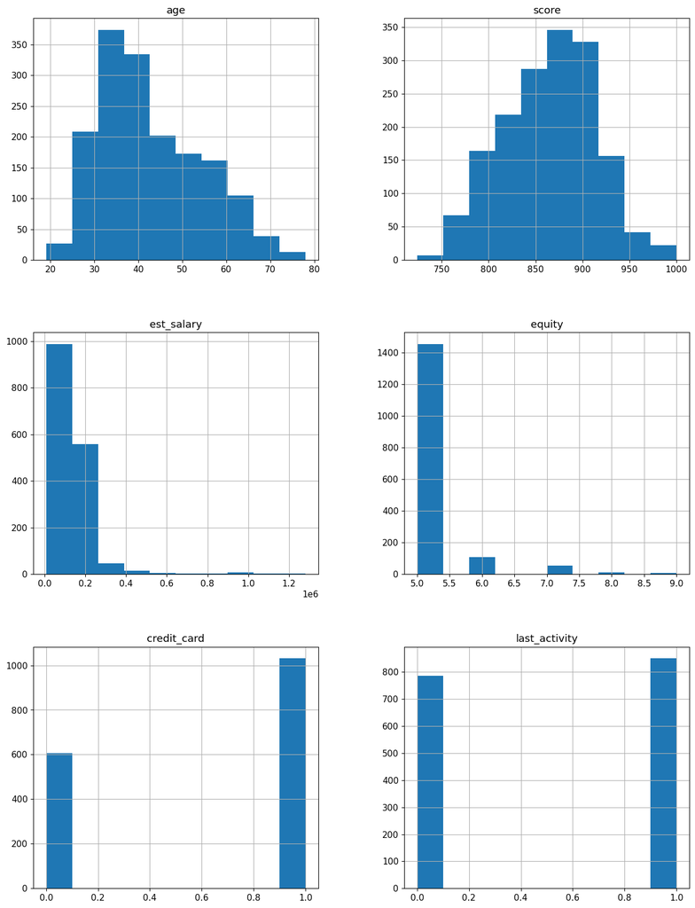

```python
# визуализация статистики для "автомобилистов"
(motorist[['age', 'score', 'est_salary',
           'equity', 'credit_card', 'last_activity']]
 .hist(figsize=(15, 20)));
```

### Сегмент №4

```python
# несколько строк из сегмента №4
racer.head()
```

|  | userid | score | gender | age | equity | balance | products | credit_card | last_activity | est_salary | churn | Ростов | Рыбинск | Ярославль |
| --- | --- | --- | --- | --- | --- | --- | --- | --- | --- | --- | --- | --- | --- | --- |
| 1 | 146556 | 861.00 | 0 | 37 | 5 | 850,594.33 | 3 | 1 | 0 | 86,621.77 | 0 | 0 | 1 | 0 |
| 72 | 156677 | 873.00 | 1 | 39 | 5 | 915,959.85 | 3 | 0 | 1 | 154,034.62 | 1 | 0 | 0 | 1 |
| 76 | 213688 | 922.00 | 0 | 37 | 5 | 1,214,707.38 | 4 | 0 | 1 | 85,121.07 | 0 | 0 | 0 | 1 |
| 81 | 223978 | 850.00 | 1 | 34 | 5 | 351,583.16 | 4 | 0 | 1 | 115,354.97 | 1 | 0 | 1 | 0 |
| 148 | 122769 | 868.00 | 0 | 58 | 5 | 1,334,745.59 | 4 | 0 | 1 | 63,049.60 | 1 | 1 | 0 | 0 |

```python
# общая статистика по сегменту №4
racer.describe()
```

|  | userid | score | gender | age | equity | balance | products | credit_card | last_activity | est_salary | churn | Ростов | Рыбинск | Ярославль |
| --- | --- | --- | --- | --- | --- | --- | --- | --- | --- | --- | --- | --- | --- | --- |
| count | 542.00 | 542.00 | 542.00 | 542.00 | 542.00 | 542.00 | 542.00 | 542.00 | 542.00 | 542.00 | 542.00 | 542.00 | 542.00 | 542.00 |
| mean | 174,356.90 | 868.67 | 0.59 | 43.81 | 5.25 | 1,361,746.89 | 3.43 | 0.46 | 0.58 | 146,563.64 | 0.49 | 0.11 | 0.16 | 0.73 |
| std | 36,188.38 | 51.92 | 0.49 | 12.31 | 0.64 | 2,115,969.38 | 0.52 | 0.50 | 0.49 | 145,167.77 | 0.50 | 0.31 | 0.37 | 0.44 |
| min | 95,384.00 | 751.00 | 0.00 | 22.00 | 5.00 | 56,925.47 | 3.00 | 0.00 | 0.00 | 8,226.26 | 0.00 | 0.00 | 0.00 | 0.00 |
| 25% | 145,070.25 | 832.25 | 0.00 | 35.00 | 5.00 | 569,660.13 | 3.00 | 0.00 | 0.00 | 69,960.43 | 0.00 | 0.00 | 0.00 | 0.00 |
| 50% | 177,111.00 | 868.00 | 1.00 | 41.00 | 5.00 | 986,723.99 | 3.00 | 0.00 | 1.00 | 114,027.58 | 0.00 | 0.00 | 0.00 | 1.00 |
| 75% | 207,114.50 | 909.00 | 1.00 | 53.00 | 5.00 | 1,539,196.74 | 4.00 | 1.00 | 1.00 | 179,437.10 | 1.00 | 0.00 | 0.00 | 1.00 |
| max | 229,017.00 | 987.00 | 1.00 | 76.00 | 9.00 | 43,277,099.84 | 5.00 | 1.00 | 1.00 | 1,363,549.52 | 1.00 | 1.00 | 1.00 | 1.00 |

Общий признак этого сегмента - от 5 баллов собственности и более 2 банковских продукта.  
Мужчин больше, чем женщин. Активных клиентов больше, чем неактивных.  
Кредитной картой владеют 46%. Средний баланс - 1.3 миллиона.  
Средний возраст 43-44 года.  
Ушедших в отток - 49%.

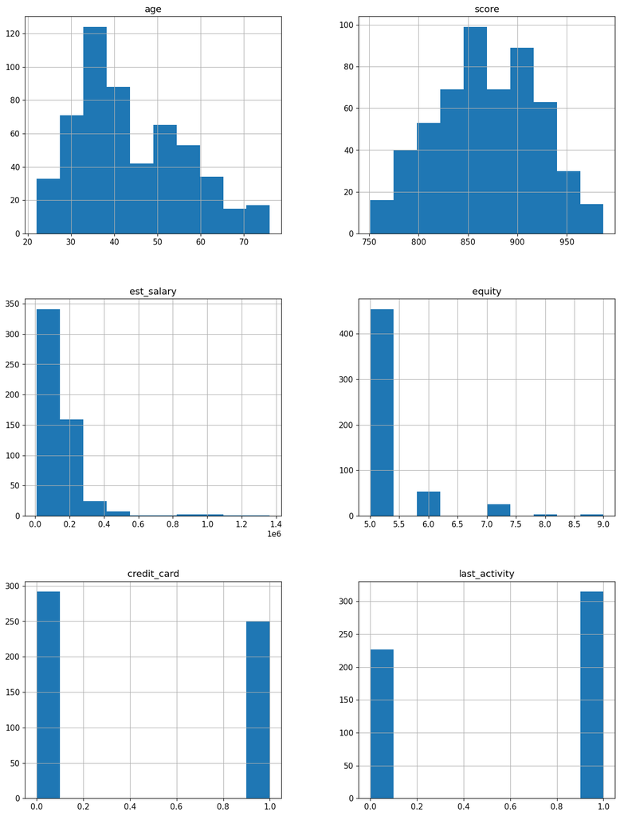

```python
# визуализация статистики для "гонщиков"
(racer[['age', 'score', 'est_salary',
           'equity', 'credit_card', 'last_activity']]
 .hist(figsize=(15, 20)));
```

### Вывод 5

Мы разделили клиентов банка на 4 сегмента по двум признакам - балл собственности и количество продуктов.  
На первое и второе место по доле отточных клиентов вышли "гонщики" и "байкеры" - 49% и 35% соответственно.  
Общий признак для них - это использование от 3 до 5 банковских продуктов, а также доля владельцев кредитной карты - 46%.  
Отличаются в этих группах баланс и гендерный состав: в группе "байкеров" чуть больше женщин и средний баланс 890 тысяч,  
а в группе "гонщиков" больше мужчин и средний баланс 1.3 миллиона.

## Рекомендации

В первую очередь следует обратить внимание на сегмент №4 ("гонщики"), и сегмент №2 ("байкеры"),  
в которые вошли клиенты, использующие от 3 до 5 банковских продукта.  
Доля отточных в этих сегментах самая большая по сравнению с другими сегментами и составляет 49% для "гонщиков" и 35% для "байкеров".

Можно предположить, что отток в этих группах связан с неудовлетворенностью инструментами управления продуктами.  
Чем больше продуктов, тем больше внимания и компетенций требуется для согласованной работы с ними.  
Из этого следует, что инструменты управления продуктами, предоставляемые банком клиенту,  
должны быть скоординированы между собой.

В идеале лучше, чтобы это был один инструмент, позволяющий управлять различными продуктами как одной системой.  
При этом быстро, удобно и понятно.

Кроме того, клиенты склонны искать более выгодные предложения  
и, скорее всего, рассматривают конкурентов с такими же банковскими продуктами.  
Если с одним-двумя продуктами довольно легко принять решение, выбрав более выгодные условия,  
то в случае с большим количеством продуктов необходимо искать баланс, а где-то и компромисс, что уже немного более сложная задача.

Другими словами, клиентам нужен удобный и эффективный инструмент управления продуктами.  
Возможно, с личным ассистентом на базе ИИ, учитывающим контекст и историю клиента.

## Общий вывод

Исследование показало наличие проблем с клиентами, которые пользуются 4-5 банковскими продуктами и имеют сравнительно большие суммы на счёте. Их отток может быть связан с неудовлетворённостью тем, как банк осуществляет обслуживание по нескольким продуктам одновременно. Возможно, они ищут большей согласованности между различными продуктами, сбалансированности преимуществ, которые даёт каждый продукт, и более удобный инструмент управления своей финансовой активностью.